# Field notes from a cool instrument

A dark-mode Quarto template tuned for long-form analytical writing, with one bold typographic moment at the title and quiet discipline everywhere else.

template

design

dark-mode

Every component shipped with the template, rendered in a single page so the type, palette, and rhythm can be audited end to end.

Author

David Sestu

Published

June 16, 2026

A notebook should make its argument easy to follow. This template keeps the visual language quiet — a cool deep-blue base, warm cream text, a single sodium-amber accent — so the analysis stays in the foreground.

Type and code are both set in **Geist**, with **Geist Mono** for monospace. Hierarchy is built from weight contrast within one family rather than face contrast across two. The palette runs from `#0e1116` at the page edge up through `#1a1f27` for code surfaces, with `#f0b232` reserved for emphasis and active states.

## Headings & hierarchy

H1 reads as a title through weight and size, not through a contrasting family. H2 carries a small amber tick above it instead of a rule beneath — a section break without the newspaper move. H3 and below stay smaller and tighter.

### A third-level heading

Reads as a divider, not a banner.

#### A fourth-level heading

##### TINY MONO LABEL

For tagging blocks of metadata or run identifiers.

## Prose, emphasis, and inline elements

Body text is Geist with a 1.6 line-height. Emphasis uses *Geist italic* — quiet, not theatrical. Inline `code` is set in Geist Mono with subtle surface fill. You can ==highlight a phrase== with `mark`, render `⌘` + `K` as keyboard shortcuts, and use abbreviations like MRR with a dotted underline.

Links underline in amber with a low-opacity stroke that solidifies on hover; [external links](https://quarto.org) do not get an arrow — the underline color already tells you everything.

> “The reason we’re building this is not aesthetics — it’s that good design is the externalization of careful thinking. If the document looks careful, the reader gives the argument more room.”

> — *Anonymous, after too much coffee*

## Callouts

Five flavors, each desaturated to sit quietly against the dark base.

**A note**

Use notes for context that helps a reader without being load-bearing.

**A tip**

Tips highlight a recommended path. Reach for them sparingly.

**A warning**

Warnings flag things that could break — silent failures, performance cliffs, edge cases. The amber here is the same one as the brand accent, so warnings double as gentle emphasis.

**Important**

Important callouts are for non-negotiable constraints: data semantics, security boundaries, compliance.

**A caution**

Cautions are for actions the reader can take that are not easily reversible.

The simple variant drops the box and keeps only a colored left rule:

A simple-style callout — minimal chrome, left bar only.

## Code blocks

Code blocks sit on the surface tone with a hairline border, rounded just enough to feel made, with a small monospace language tag in the top-right. Copy buttons reveal on hover.

```python
from __future__ import annotations
import polars as pl

def monthly_recurring_revenue(invoices: pl.DataFrame) -> pl.DataFrame:
    """Normalize all billing periods to a monthly cadence."""
    return (
        invoices
        .filter(pl.col("status") == "paid")
        .with_columns(
            mrr=pl.when(pl.col("period") == "yearly")
              .then(pl.col("amount") / 12)
              .otherwise(pl.col("amount"))
        )
        .group_by(pl.col("invoice_date").dt.truncate("1mo"))
        .agg(pl.col("mrr").sum().alias("total_mrr"))
        .sort("invoice_date")
    )
```

```sql
-- Subscriptions with at least one paid invoice in the last 30 days
select
    s.id           as subscription_id,
    s.customer_id,
    s.plan_id,
    sum(i.amount)  as revenue_30d
from subscriptions s
join invoices i on i.subscription_id = s.id
where i.status = 'paid'
  and i.paid_at >= now() - interval '30 days'
group by 1, 2, 3
order by revenue_30d desc
limit 25;
```

```r
library(ggplot2)
ggplot(mpg, aes(displ, hwy, color = class)) +
  geom_point(alpha = 0.7, size = 2.5) +
  geom_smooth(method = "loess", se = FALSE) +
  scale_color_viridis_d(option = "magma") +
  theme_minimal(base_family = "Geist")
```

Inline `python` like `df.groupby('region').agg('sum')` flows into prose without breaking the baseline.

## Tables

Tables get a hairline border, rounded corners, mono-caps headers, and tabular figures via `.numeric`.

Active stations and connection density by region

| Region | Stations | Active rate | Avg connections / day |
| --- | --- | --- | --- |
| France | 12,847 | 82.4% | 1.42 |
| Spain | 3,210 | 77.1% | 1.18 |
| Germany | 2,508 | 88.9% | 1.61 |
| Italy | 1,892 | 73.0% | 0.97 |
| United States | 441 | 65.8% | 0.84 |

## Figures

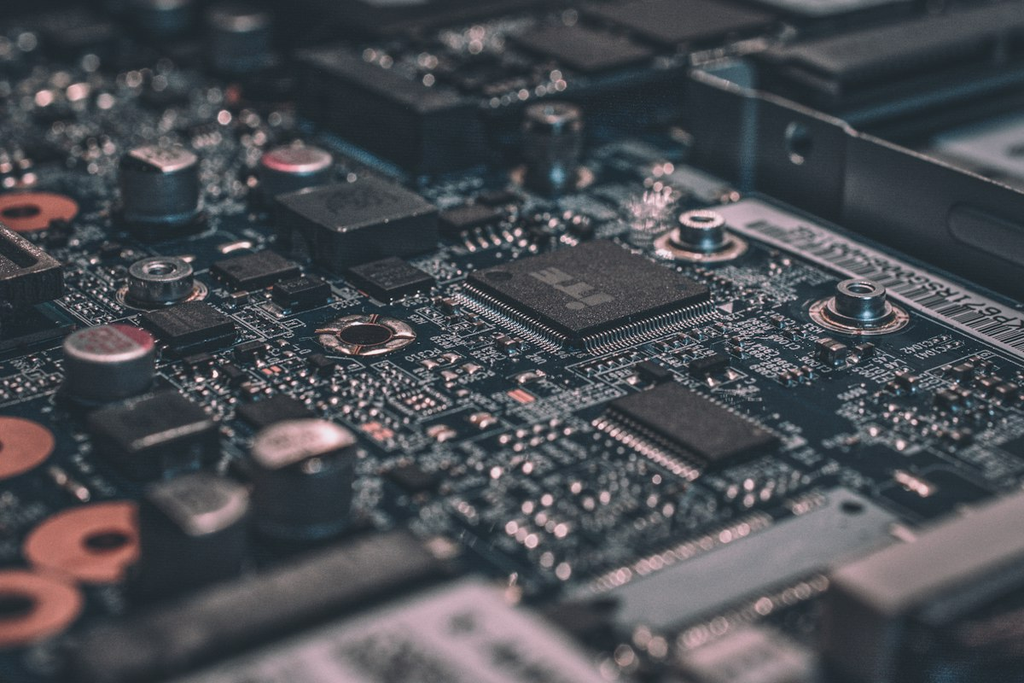

Cross-reference it as Figure 1 for a hover popup.

## Math

Inline math like $e^{i\pi} + 1 = 0$ flows in the baseline. Display math gets generous vertical space:

$$\operatorname{MRR}_t = \sum_{s \in \mathcal{S}_t}
\begin{cases}
\dfrac{\text{amount}_s}{12} & \text{if billing}_s = \text{yearly} \\[6pt]
\dfrac{\text{amount}_s}{3} & \text{if billing}_s = \text{quarterly} \\[6pt]
\text{amount}_s & \text{if billing}_s = \text{monthly}
\end{cases}
\tag{1}$$

Reference equations with Equation 1.

## Lists

Bulleted lists use an amber marker:

- Generous line-height for scannable items.
- Nested lists inherit the same rhythm.
  - Second level
  - With its own marker color
- A tighter top margin keeps adjacent text close.

Numbered lists are equally restrained:

1. First, define the question.
2. Then, pick the smallest dataset that answers it.
3. Finally, ship the chart.

Definition lists:

**API**

The interface another developer talks to.

**UX**

The interface your user talks to.

## Footnotes

Footnote markers sit as small rounded mono pills[^1] — quieter than the default superscript. Hover for the contents; the full list collects at the bottom.[^2]

## Keyboard shortcuts and abbreviations

Press `Ctrl` + `Shift` + `P` to open the command palette. Acronyms like ARR render with a dotted underline.

## A horizontal rule

The horizontal rule is a short centered hairline — a quiet break rather than a decorative fleuron.

## Cell outputs

Below is how Jupyter cell outputs render in this template — set on a deeper surface so they read as the document’s quiet voice replying to the code.

```python
df.head()
```

```
   region  stations  active_rate
0  France     12847        0.824
1  Spain       3210        0.771
2  Germany    2508         0.889
```

## Section accordion

Click any section heading to collapse or expand its content. Sections with the `{.collapsed}` attribute start collapsed by default.

### A normally-expanded subsection

This subsection is open at first load. Clicking the heading toggles it.

### Long content collapses cleanly

This subsection starts collapsed because the source has `### Heading {.collapsed}`. The chevron rotates and the body’s height animates to zero.

```python
def example():
    return "hidden until expanded"
```

## Closing notes

Every color is a CSS custom property in `theme.scss`. To change the accent — say from amber to a cooler instrument cyan — edit `--c-accent` and `--c-accent-bright`. To change the type family, override `mainfont` in `_quarto.yml` and `$font-family-sans-serif` in `theme.scss`.

Render with `quarto render template.qmd` from the template directory.

## Footnotes

[^1]: Inspired by Stripe Press: small, restrained, unmistakable.
[^2]: With a generous top border so the footnote section reads as its own register.